# BCCM Results Over Full Domain

Andrew Edwards and Travis Tai

Last rendered on 12 May, 2026

# Introduction

The British Columbia Continental Margin (BCCM) model is a physical biogeochemical oceanographic model, implemented using the Regional Ocean Modeling System (ROMS; Peña et al., 2019). Results restricted to Canada’s Exclusive Economic Zone and mapped to a 2 km x 2 km grid onshore and 6 x 6 km grid offshore are discussed in the BCCM Results vignette, which should be looked at to understand more about the model. The restrictions and varying of the gridsize were done to reduce file sizes.

Due to several requests from users we have now also mapped the BCCM results for its full domain (extending north and south into US waters) onto a 2 km x 2km grid. These requests included:

- [Issue #49](https://github.com/pbs-assess/pacea/issues/49): extend the BCCM results into US waters
- [Issue #58](https://github.com/pbs-assess/pacea/issues/58): add the results from the HOTSSea physical oceanographic model for the Salish Sea (a region not covered by the BCCM results, ideally on a grid that overlaps as that used for the BCCM
- [Issue #48](https://github.com/pbs-assess/pacea/issues/48) and [Issue #62](https://github.com/pbs-assess/pacea/issues/62): have an easily exported grid that covers a larger domain
- [Issue #60](https://github.com/pbs-assess/pacea/issues/60): projecting the Optimally Interpolated Sea Surface Temperature values onto the same grid as the BCCM results.

These requests are now mostly fulfilled, and include the BCCM results on the full domain. The results are in the same format as those for the restricted domain described in the BCCM Results vignette vignette. The file sizes are much larger (each variable is about 120 Mb rather than about 30 Mb), but only need to be downloaded once.

We have kept consistent terminology and functionality as for the restricted BCCM results. Basically: - variable names are appended with `_full` - plotting and analysis functions should still work on the `_full` variables.

Deciding if you need the `_full` outputs or just the original over Canada’s EEZ:

- use the original if you want OISST data on its original grid (unrelated to BCCM grid) over the EEZ, and/or BCCM over EEZ, and don’t want to do spatiotemporal modelling involve both of those or also involving HOTSSea output (it is okay for you if the BCCM and HOTSSea grids do not overlap) – use existing variables
- if you want anything else, like OISST or BCCM extended to a larger domain, HOTSSea and/or OISST and/or BCCM on the same grid (especially for spatiotemporal analyses) - use the new BCCM `_full` variables described here.

## Available variables

```r
library(pacea)
library(dplyr)
library(sf)
library(ggplot2)
```

For the restricted domain, the available variables are given in the data object `bccm_data`. For the full domain, the variables are therefore given in `bccm_data_full`:

```r
bccm_data_full
#                             data_name
# 1            bccm_surface_oxygen_full
# 2                bccm_surface_ph_full
# 3          bccm_surface_salinity_full
# 4       bccm_surface_temperature_full
# 5          bccm_avg0to40m_oxygen_full
# 6              bccm_avg0to40m_ph_full
# 7        bccm_avg0to40m_salinity_full
# 8     bccm_avg0to40m_temperature_full
# 9        bccm_avg40to100m_oxygen_full
# 10           bccm_avg40to100m_ph_full
# 11     bccm_avg40to100m_salinity_full
# 12  bccm_avg40to100m_temperature_full
# 13      bccm_avg100mtoBot_oxygen_full
# 14          bccm_avg100mtoBot_ph_full
# 15    bccm_avg100mtoBot_salinity_full
# 16 bccm_avg100mtoBot_temperature_full
# 17            bccm_bottom_oxygen_full
# 18                bccm_bottom_ph_full
# 19          bccm_bottom_salinity_full
# 20       bccm_bottom_temperature_full
# 21            bccm_phytoplankton_full
# 22        bccm_primaryproduction_full
```

The `bccm_data` object gives the same 22 names, but without the `_full`.

## Downloading bccm full results

The 22 BCCM full model results are stored on Zenodo at https://zenodo.org/records/14031460. Each can be downloaded individually (if you only want certain variables) as described below. It is easiest to just just simply download them all to your computer in one go, using

```r
bccm_all_variables_full()
```

This places them into a cache directory on your local machine, given by by `paste0(pacea_cache(), "/bccm_full")`. It only took about 10 minutes to download them all (the code uses parallel cores on Windows) on a home network, but could be longer on a work network. You can check progress in your local cache directory, where files should gradually appear. Any files that are already present in your cache directory are not re-downloaded. See `?bccm_all_variables_full` if you have problems.

### Using the bccm full results

As an example, let’s look at the estimates of primary production, calling the object `pp` locally:

```r
pp <- bccm_primaryproduction_full()
```

Note the `()`. The `bccm_primaryproduction_full()` function assigns the output to our designated variable simply named `pp`.

If you have not already previously downloaded the relevant results it will first download them into your cache folder (i.e. it will get just the specified model results, rather than all of them as in the `bccm_all_variables_full()` described above). If you have previously downloaded the results the function will simply load them in from your cached folder.

View the data help for more information (e.g. `?bccm_primaryproduction_full`); similar help functions all point to a common help file for all `bccm_full` objects.

So, what does the object look like?

```r
pp
# Simple feature collection with 161025 features and 324 fields
# Geometry type: POLYGON
# Dimension:     XY
# Bounding box:  xmin: 108882.9 ymin: -165260 xmax: 1160883 ymax: 1192740
# Projected CRS: NAD83 / BC Albers
# # A tibble: 161,025 × 325
#    `1993_1` `1993_2` `1993_3` `1993_4` `1993_5` `1993_6` `1993_7` `1993_8`
#  *    <dbl>    <dbl>    <dbl>    <dbl>    <dbl>    <dbl>    <dbl>    <dbl>
#  1   0.0840    0.335    0.726    0.796    1.05     0.827    0.845    0.792
#  2   0.0827    0.328    0.747    0.831    1.05     0.834    0.852    0.800
#  3   0.0866    0.344    0.717    0.801    1.07     0.860    0.872    0.813
#  4   0.0855    0.337    0.753    0.861    1.07     0.858    0.867    0.813
#  5   0.0841    0.332    0.757    0.858    1.07     0.848    0.860    0.807
#  6   0.0903    0.349    0.747    0.862    1.09     0.870    0.881    0.823
#  7   0.0887    0.344    0.775    0.904    1.09     0.874    0.878    0.822
#  8   0.0870    0.339    0.773    0.900    1.09     0.867    0.873    0.816
#  9   0.0637    0.251    0.579    0.668    0.807    0.642    0.650    0.606
# 10   0.0691    0.266    0.570    0.649    0.821    0.651    0.658    0.616
# # ℹ 161,015 more rows
# # ℹ 317 more variables: `1993_9` <dbl>, `1993_10` <dbl>, `1993_11` <dbl>,
# #   `1993_12` <dbl>, `1994_1` <dbl>, `1994_2` <dbl>, `1994_3` <dbl>,
# #   `1994_4` <dbl>, `1994_5` <dbl>, `1994_6` <dbl>, `1994_7` <dbl>,
# #   `1994_8` <dbl>, `1994_9` <dbl>, `1994_10` <dbl>, `1994_11` <dbl>,
# #   `1994_12` <dbl>, `1995_1` <dbl>, `1995_2` <dbl>, `1995_3` <dbl>,
# #   `1995_4` <dbl>, `1995_5` <dbl>, `1995_6` <dbl>, `1995_7` <dbl>, …
head(pp[, 1:5])   # note that the geometry column is included when selecting columns from
# Simple feature collection with 6 features and 5 fields
# Geometry type: POLYGON
# Dimension:     XY
# Bounding box:  xmin: 626882.9 ymin: 1186740 xmax: 634882.9 ymax: 1192740
# Projected CRS: NAD83 / BC Albers
# # A tibble: 6 × 6
#   `1993_1` `1993_2` `1993_3` `1993_4` `1993_5`                          geometry
#      <dbl>    <dbl>    <dbl>    <dbl>    <dbl>                     <POLYGON [m]>
# 1   0.0840    0.335    0.726    0.796     1.05 ((630882.9 1192740, 632882.9 119…
# 2   0.0827    0.328    0.747    0.831     1.05 ((632882.9 1192740, 634882.9 119…
# 3   0.0866    0.344    0.717    0.801     1.07 ((628882.9 1190740, 630882.9 119…
# 4   0.0855    0.337    0.753    0.861     1.07 ((630882.9 1190740, 632882.9 119…
# 5   0.0841    0.332    0.757    0.858     1.07 ((632882.9 1190740, 634882.9 119…
# 6   0.0903    0.349    0.747    0.862     1.09 ((626882.9 1188740, 628882.9 118…
                  # an `sf` object.
```

The object is in wide format, with each column representing a unique year-month combination, and is a ‘simple features’ (`sf`) R object, and so contains a `geometry` column. The data also have various attributes, such as the units for the data values, and some extra ones to automate some plotting. (This is useful but not essential for users to know).

```r
names(attributes(pp))
# [1] "names"     "row.names" "class"     "sf_column" "agr"       "units"
# [7] "bccm_full"
attributes(pp)$units
#                                vars_units
# "Total primary production (gC m^-2 d^-1)"
class(pp)
# [1] "pacea_st"   "sf"         "tbl_df"     "tbl"        "data.frame"
```

## Visualising the bccm full results

We give some examples here, and then refer users to the BCCM Results vignette since the examples shown there should work for the `_full` results. (Note we have not tested every potential idea you might have, but by keeping the structure of the outputs the same, our custom plotting and analysis functions should work).

### Plotting with `plot()`

Results can be plotted using the `plot()` function (that we have customised). The default settings are to plot results for April, 2018. However, users can specify any time period(s) available in the results. Examples are:

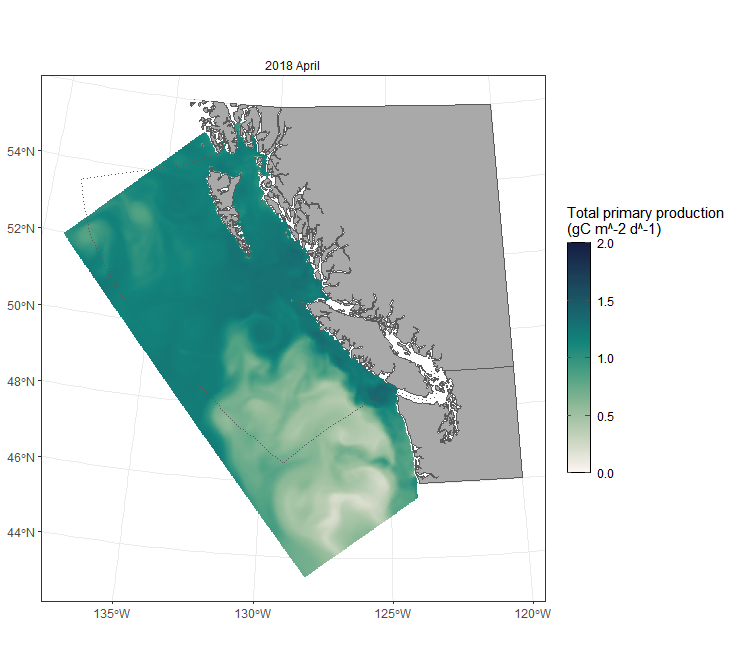

```r
plot(pp)
```

To see the estimated primary production for each month of 2018

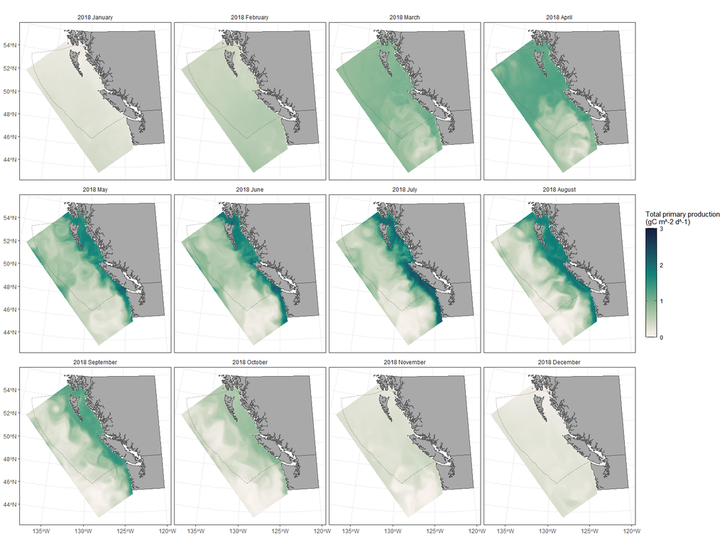

```r
plot(pp, months = 1:12)
```

This shows the production ramping up through the spring.

### Climatologies and anomalies

Let’s have a quick look at anomalies, say for oxygen at the bottom of the water column, adapting the examples from the [BCCM vignette](https://pbs-assess.github.io/pacea/vignettes/bccm.html). Again, see that vignette for extra details.

We can easily load the model results and calculate the anomalies for a climatology (see `?calc_clim` to obtain the climatology also):

```r
bottom_oxygen <- bccm_bottom_oxygen_full()
anom <- calc_anom(bottom_oxygen,
                  clim_years = 1993:2010,
                  time_period_return = c("Apr", "Sep"),
                  years_return = c(2010, 2018))
anom
# Simple feature collection with 161025 features and 4 fields
# Geometry type: POLYGON
# Dimension:     XY
# Bounding box:  xmin: 108882.9 ymin: -165260 xmax: 1160883 ymax: 1192740
# Projected CRS: NAD83 / BC Albers
# # A tibble: 161,025 × 5
#    `2010_4` `2010_9` `2018_4` `2018_9`                                  geometry
#       <dbl>    <dbl>    <dbl>    <dbl>                             <POLYGON [m]>
#  1     21.3     8.75    -24.7    -23.3 ((630882.9 1192740, 632882.9 1192740, 63…
#  2     21.3     8.75    -24.7    -23.3 ((632882.9 1192740, 634882.9 1192740, 63…
#  3     21.3     8.70    -24.8    -23.2 ((628882.9 1190740, 630882.9 1190740, 63…
#  4     21.3     8.75    -24.7    -23.3 ((630882.9 1190740, 632882.9 1190740, 63…
#  5     21.3     8.75    -24.7    -23.3 ((632882.9 1190740, 634882.9 1190740, 63…
#  6     21.4     9.09    -25.2    -22.4 ((626882.9 1188740, 628882.9 1188740, 62…
#  7     21.4     8.83    -25.1    -22.8 ((628882.9 1188740, 630882.9 1188740, 63…
#  8     21.4     8.89    -24.9    -22.9 ((630882.9 1188740, 632882.9 1188740, 63…
#  9     21.3     8.75    -24.7    -23.3 ((632882.9 1188740, 634882.9 1188740, 63…
# 10     21.4     9.77    -25.8    -21.2 ((624882.9 1186740, 626882.9 1186740, 62…
# # ℹ 161,015 more rows
```

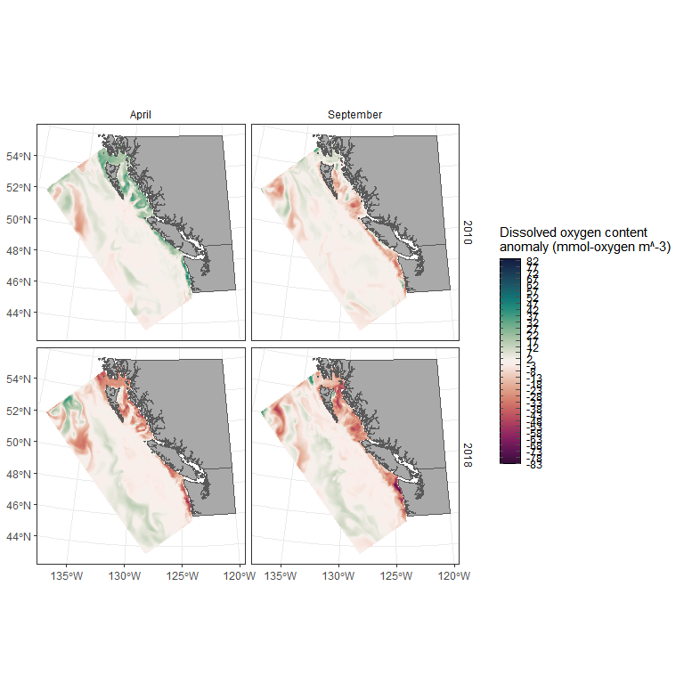

```r
plot(anom,
     months.plot = c("Apr", "Sep"),
     years.plot = c(2010, 2018),
     eez = FALSE)
```

So some areas are relatively oxygen rich (green) in these months compared to the same areas from 1993 to 2010, whereas others are lower in oxygen (red). This varies spatially and by month. Along the coast there looks to be more oxygen than normal in April 2010, generally a bit less in September 2010, and even less in April and September 2018.

See the [BCCM vignette](https://pbs-assess.github.io/pacea/vignettes/bccm.html) for further example calculations, which hopefully stimulate your own ideas.

## Reference

Peña, M.A., Fine, I. and Callendar, W. 2019. Interannual variability in primary production and shelf-offshore transport of nutrients along the northeast Pacific Ocean margin. Deep-Sea Research II, doi:10.1016/j.dsr2.2019.104637.